# Feature Engineering

## Where we left off

- **Days 5-7:** understanding your data
  - plotting it
  - finding what moves together
  - cleaning what’s broken
- **Today:** reshaping it for a model
- The raw columns you’re handed are rarely the ones that predict best
- **Feature engineering** = building better ones

## Today’s dataset: `Auto`

From ISLR2 — 392 cars from the 1970s and 80s.

| Variable | Meaning |
| --- | --- |
| `mpg` | Miles per gallon — **what we want to predict** |
| `horsepower` | Engine power |
| `weight`, `displacement` | Size of the car and its engine |
| `year` | Model year (70 = 1970) |
| `origin` | 1 = American, 2 = European, 3 = Japanese |

```r
data(Auto)
dim(Auto)
## [1] 392   9
```

## The question, and a baseline

> **What predicts a car’s fuel economy?**

Obvious first guess: horsepower. More power, worse mileage.

```r
cor(Auto$mpg, Auto$horsepower)
## [1] -0.7784268
```

Strong and negative, as expected. To compare features we need one number: **R-squared**, the share of the variation in `mpg` that a model explains.

```r
summary(lm(mpg ~ horsepower, data = Auto))$r.squared
## [1] 0.6059483
```

Horsepower alone explains about **61%**. That’s the **baseline** — every feature we build today has to beat 0.61.

## 1. Transform what you have

## Straight lines don’t fit everything

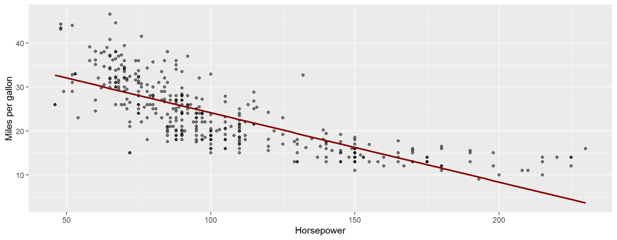

The line **sits below the data at both ends and above it in the middle.** The relationship is real, but it isn’t straight — it bends.

## A polynomial feature

If the relationship bends, give the model something that can bend. Square the predictor and include both terms:

```r
Auto <- Auto %>% mutate(hp2 = horsepower^2)

summary(lm(mpg ~ horsepower + hp2, data = Auto))$r.squared
## [1] 0.687559
```

**0.61 → 0.69.** Same information, better shape.

We didn’t collect any new data. We gave the model a variable it could use.

## Linear vs. polynomial

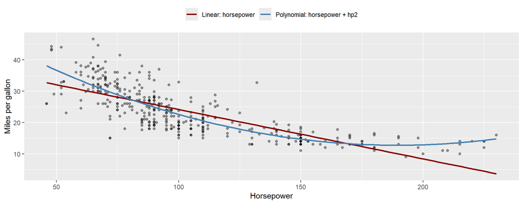

The polynomial **bends with the data**: it follows the steep drop at low horsepower and flattens out at the high end, where the straight line misses.

## 2. Turn categories into numbers

## The problem

- `origin` is a category: 1 = American, 2 = European, 3 = Japanese
- Those numbers are **labels, not quantities**
  - a European car isn’t “twice” an American one
- Feed `origin` to a model as-is and you’ve told it something false

```r
Auto %>% count(origin)
##   origin   n
## 1      1 245
## 2      2  68
## 3      3  79
```

## Indicator (dummy) variables

The fix: a **binary variable** — 1 if the row is in the category, 0 if not.

```r
Auto <- Auto %>% mutate(imported = if_else(origin == 1, 0, 1))

Auto %>% group_by(imported) %>%
  summarise(n = n(), mean_mpg = round(mean(mpg), 1))
## # A tibble: 2 × 3
##   imported     n mean_mpg
##      <dbl> <int>    <dbl>
## 1        0   245     20
## 2        1   147     29.1
```

Imported cars average **9 mpg better**. That’s a real, usable signal — and now it’s in a form a model can take.

## More than two categories

- Three or more levels: **one indicator per level** (*one-hot* or *dummy* encoding)
- One `if_else()` per level gets tedious fast (50 states, 200 zip codes)
- `dummy_cols()` from `fastDummies` builds them all at once:

```r
Auto %>%
  dummy_cols(select_columns = "origin") %>%
  select(origin, origin_1, origin_2, origin_3) %>%
  slice(c(1, 20, 15))   # an American, a European, a Japanese car
##   origin origin_1 origin_2 origin_3
## 1      1        1        0        0
## 2      2        0        1        0
## 3      3        0        0        1
```

- You only need **two** of these three — the third is implied
- R’s `lm()` does this for you when you pass a factor

## 3. Combine what you have

## The question

We know horsepower hurts mileage. We know imports get better mileage.

But does horsepower cost the **same** for both?

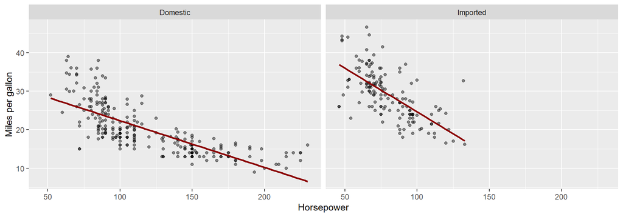

## Different slopes

Each extra unit of horsepower costs:

- **Domestic:** about **0.12** mpg
- **Imported:** about **0.23** mpg — nearly twice as steep

An `imported` indicator shifts the line **up or down**. It cannot make the line **steeper or flatter**.

To express “the effect of X depends on Z,” you need the two multiplied together.

## Interaction terms

```r
Auto <- Auto %>% mutate(hp_x_imported = horsepower * imported)

summary(lm(mpg ~ horsepower + imported, data = Auto))$r.squared
## [1] 0.6504913
summary(lm(mpg ~ horsepower + imported + hp_x_imported, data = Auto))$r.squared
## [1] 0.6720428
```

**0.650 → 0.672.** A modest gain in R-squared — but it changes the *story*: horsepower isn’t one penalty, it’s two different penalties depending on where the car was built.

Not every useful feature produces a dramatic jump in fit.

## Reading an interaction

```r
b <- coef(lm(mpg ~ horsepower + imported + hp_x_imported, data = Auto))
round(b, 3)
##   (Intercept)    horsepower      imported hp_x_imported
##        34.476        -0.121        12.864        -0.106
```

For a domestic car (`imported = 0`), the term is `horsepower * 0` = **0**. The model uses the plain horsepower slope: **-0.121**.

For an imported car (`imported = 1`), the term equals `horsepower`, and its coefficient **adds to** that slope: -0.121 + (-0.106) = **-0.227**.

Those are the two slopes from the facets. The interaction coefficient answers: *how much steeper is the relationship for this group?*

## When to stop

## Feature engineering is iterative

The loop:

1. Build a feature you have a **reason** to believe in.
2. Check whether it helps.
3. Keep it or drop it — and write down which.

Two failure modes:

- **Too few features:** the model can’t see patterns that are plainly there (the curve in horsepower).
- **Too many:** with enough invented variables, something will look predictive by chance. We’ll make this precise when we cover overfitting.

## Domain knowledge beats brute force

You created `hp2` because the **plot bent**.

You created `imported` because you knew national industries built different cars.

You created the interaction because the **facets showed different slopes**.

Every one of those came from looking at the data first — which is what Days 5-7 were for.

## Summary

- **Transform:** a polynomial term lets a straight-line model fit a curve.
- **Indicators:** `if_else(condition, 1, 0)` turns a category into something a model can use.
- **Interactions:** multiply two features when the effect of one depends on the other.
- **Judge every feature** against a baseline — here, R-squared against 0.61.
- A feature needs a **reason**, not just a better number.

## For rest of class

- Work on the `day8_activity`
- **Problem Set 2** is due Friday — Parts 3 and 4 use today’s material
- Ask me questions if you run into issues